# Analytics Edge: Unit 6 - Clustering to Better Predict Heart Attacks

Sulman Khan

October 26, 2018

## Predictive Diagnosis

### Heart Attacks

- Heart attack is a common complication of coronary heart disease resulting from the interruption of blood supply to part of the heart
- 2012 report from the American Heart Association estimates **about 715,000** Americans have a heart attack every year
  - **Every 20 seconds**, a person has a heart attack in the US
  - Nearly **half** occur without prior warning signs
  - **250,000** Americans die of Sudden Cardiac Death yearly
- Well - known symptoms
  - Chest pain, shortness of breath, upper body pain, nausea
- Nature of heart attacks make it hard to predict, prevent and even diagnose
  - **25%** of heart attacks are silent
  - **47%** of sudden cardiac deaths occur outside hospitals, suggesting many do not act on early warning signs
  - **27%** of respondents to a 2005 survey recognized the symptoms and called 911 for help

### Analytics Help Monitoring

- Understanding the clinical characteristics of patients in whom heart attack was missed is key
- Need for an increased understanding of patterns in a patient’s diagnostic history that link to a heart attack
- Predicting whether a patient is at risk of a heart attack helps monitoring and calls for action
- Analytics help **understand patterns** of heart attacks and provides good predictions

### Claims Data

- Claims data offers an expansive view of a patient’s health history
  - Demographics, medical history and medications
  - Offers insights regarding a patient’s risk
  - May reveal **indicative signals and patterns**
- We will use health insurance claims filed for about 7,000 members from January 200 - November 2007
- Concentrated on members with the following attributes
  - At least 5 claims with coronary artery disease diagnosis
  - At least 5 claims with hypertension diagnostic codes
  - At least 100 total medical claims
  - At least 5 pharmacy claims
  - Data from at least 5 years
- Yields patients with a high risk of heart attack and a reasonably rich history and continuous coverage

### Data Aggregation

- The resulting dataset includes about **20 million health insurance entries** including individual medical and pharmaceutical records
- Diagnosis, procedure, and drug codes in the dataset comprise tens of thousands of attributes
- Codes were aggregated into groups
  - 218 diagnosis groups, 180 procedure groups, 538 drug groups
  - 46 diagnosis groups were considered by clinicians as possible risk factors for heart attacks

### Diagnostic History

- We then compress medical records to obtain a chronological representation of a patient’s diagnostic profile
  - Cost and number of medical claims and hospital visits by diagnosis
- Observations split into 21 periods, each 90 days in length
  - Examined 9 months of diagnostic history leading up to heart attacks/no heart attack event
  - Align data to make observations date-independent while preserving the order of events
    - 3 months ~ 0 - 3 months before heart attack
    - 6 months ~ 3 - 6 months before heart attack
    - 9 months ~ 6 - 9 months before heart attack

### Target Variable

- Target prediction is the first occurrence of a heart attack
  - Diagnosis on medical claim
  - Visit to emergency room followed by hospitalization
  - Binary Yes/No

### Dataset Compilation

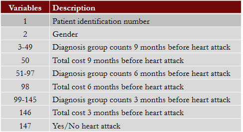

### Cost Bucket Partitioning

- Cost is a good summary of a person’s overall health
- Divide population into similar smaller groups
  - Low risk, average risk, high risk

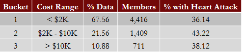

- Build models for each group

### Predicting Heart Attacks (Random Forest)

- Predicting whether a patient has a heart attack for each of the cost buckets using the random forest algorithm

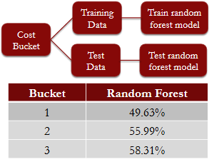

### Incorporating Clustering

- Patients in each bucket may have different characteristics

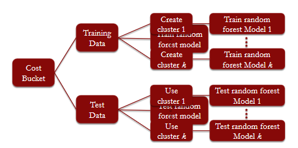

### Clustering Cost Buckets

- Two clustering algorithms were used for the analysis as an alternative to hierarchical clustering
  - Spectral Clustering
  - *k-means* clustering

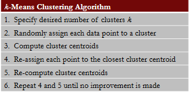

### *k* - Means Clustering

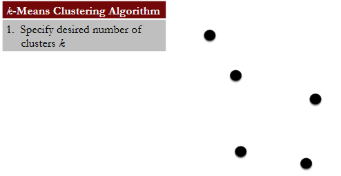

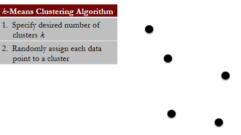

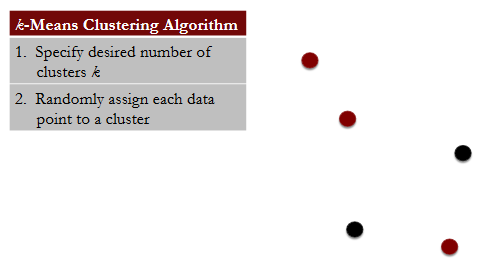

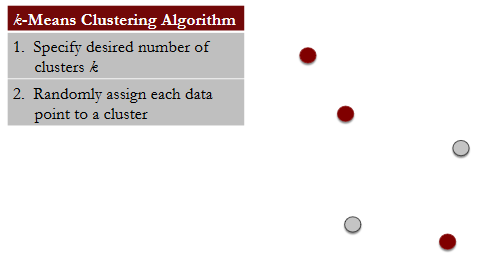

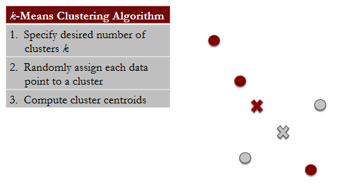

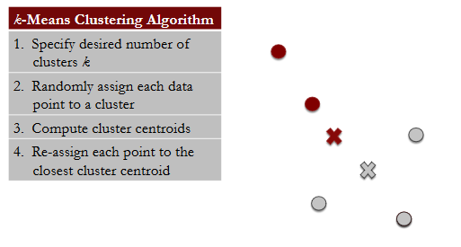

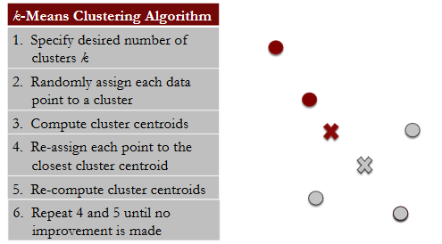

### Practical Considerations

- The number of *k* can be selected from previous knowledge or experimenting
- Can strategically select initial partition of points into clusters if you have some knowledge of the data
- Can run algorithm several times with different random starting points

### Random Forest with Clustering

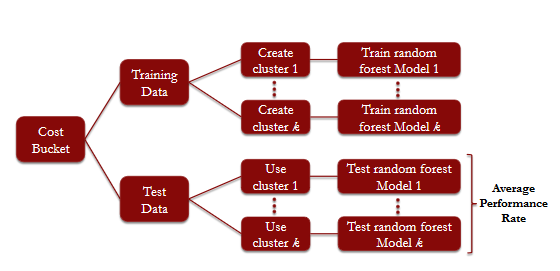

### Predicting Heart Attacks

- Perform clustering on each bucket using *k* = 10 clusters
- Average prediction rate for each cost bucket

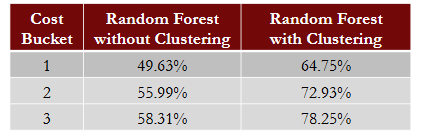

### Impact of Clustering

- Clustering members with each cost bucket yielded better predictions of heart attacks within clusters
- Grouping patients in clusters exhibit temporal diagnostic patterns within 9 months of a heart attack
- These patterns can be incorporated in the diagnostic rules for heart attacks
- Greater research interns in using analytics for early heart failure detection through pattern recognition